# Исследование данных о компьютерных играх для интернет-магазина

**Описание проекта:**

Вы работаете в интернет-магазине «Стримчик», который продаёт по всему миру компьютерные игры. Из открытых источников доступны исторические данные о продажах игр, оценки пользователей и экспертов, жанры и платформы (например, Xbox или PlayStation).

**Цель проекта**: выявить определяющие успешность игры закономерности.

**Задачи проекта**:

- изучить данные об играх в разбивке по платформам и жанрам;
- составить портрет пользователя каждого региона;
- проверить ряд гипотез.

**Используемые инструменты**

- python
- pandas
- numpy
- matplotlib
- scipy

**План работы**

1. Загрузить и данные и выполнить их предобработку.
2. Провести исследовательский анализ данных:
   - определить период времени, данные за который можно считать актуальными;
   - рассмотреть динамику продаж по платформам и жанрам;
   - изучить влияние отзывов на продажи игр в рамках платформ;
3. Составить и визуализировать портрет пользователя каждого региона.
4. Провести статистическую проверку гипотез.
5. Сделать общий вывод и сформулировать рекомендации для рекламного отдела.

**Описание данных**

- **Name** — название игры
- **Platform** — платформа
- **Year_of_Release** — год выпуска
- **Genre** — жанр игры
- **NA_sales** — продажи в Северной Америке (миллионы проданных копий)
- **EU_sales** — продажи в Европе (миллионы проданных копий)
- **JP_sales** — продажи в Японии (миллионы проданных копий)
- **Other_sales** — продажи в других странах (миллионы проданных копий)
- **Critic_Score** — оценка критиков (максимум 100)
- **User_Score** — оценка пользователей (максимум 10)
- **Rating** — рейтинг от организации ESRB (англ. Entertainment Software Rating Board). Эта ассоциация определяет рейтинг компьютерных игр и присваивает им подходящую возрастную категорию.

Данные за 2016 год могут быть неполными.

```python
#импорт средств для отображения пропусков
!pip install missingno
import missingno as msno

#импорт необходимых библиотек
import pandas as pd

import matplotlib.pyplot as plt

import numpy as np

from scipy import stats as st
```

## Загрузка данных

Датасет **games_csv**: загрузка, первые 20 строк, основная информация

```python
data = pd.read_csv('games.csv')

data.head(20)
```

|  | Name | Platform | Year_of_Release | Genre | NA_sales | EU_sales | JP_sales | Other_sales | Critic_Score | User_Score | Rating |
| --- | --- | --- | --- | --- | --- | --- | --- | --- | --- | --- | --- |
| 0 | Wii Sports | Wii | 2006.0 | Sports | 41.36 | 28.96 | 3.77 | 8.45 | 76.0 | 8 | E |
| 1 | Super Mario Bros. | NES | 1985.0 | Platform | 29.08 | 3.58 | 6.81 | 0.77 | NaN | NaN | NaN |
| 2 | Mario Kart Wii | Wii | 2008.0 | Racing | 15.68 | 12.76 | 3.79 | 3.29 | 82.0 | 8.3 | E |
| 3 | Wii Sports Resort | Wii | 2009.0 | Sports | 15.61 | 10.93 | 3.28 | 2.95 | 80.0 | 8 | E |
| 4 | Pokemon Red/Pokemon Blue | GB | 1996.0 | Role-Playing | 11.27 | 8.89 | 10.22 | 1.00 | NaN | NaN | NaN |
| 5 | Tetris | GB | 1989.0 | Puzzle | 23.20 | 2.26 | 4.22 | 0.58 | NaN | NaN | NaN |
| 6 | New Super Mario Bros. | DS | 2006.0 | Platform | 11.28 | 9.14 | 6.50 | 2.88 | 89.0 | 8.5 | E |
| 7 | Wii Play | Wii | 2006.0 | Misc | 13.96 | 9.18 | 2.93 | 2.84 | 58.0 | 6.6 | E |
| 8 | New Super Mario Bros. Wii | Wii | 2009.0 | Platform | 14.44 | 6.94 | 4.70 | 2.24 | 87.0 | 8.4 | E |
| 9 | Duck Hunt | NES | 1984.0 | Shooter | 26.93 | 0.63 | 0.28 | 0.47 | NaN | NaN | NaN |
| 10 | Nintendogs | DS | 2005.0 | Simulation | 9.05 | 10.95 | 1.93 | 2.74 | NaN | NaN | NaN |
| 11 | Mario Kart DS | DS | 2005.0 | Racing | 9.71 | 7.47 | 4.13 | 1.90 | 91.0 | 8.6 | E |
| 12 | Pokemon Gold/Pokemon Silver | GB | 1999.0 | Role-Playing | 9.00 | 6.18 | 7.20 | 0.71 | NaN | NaN | NaN |
| 13 | Wii Fit | Wii | 2007.0 | Sports | 8.92 | 8.03 | 3.60 | 2.15 | 80.0 | 7.7 | E |
| 14 | Kinect Adventures! | X360 | 2010.0 | Misc | 15.00 | 4.89 | 0.24 | 1.69 | 61.0 | 6.3 | E |
| 15 | Wii Fit Plus | Wii | 2009.0 | Sports | 9.01 | 8.49 | 2.53 | 1.77 | 80.0 | 7.4 | E |
| 16 | Grand Theft Auto V | PS3 | 2013.0 | Action | 7.02 | 9.09 | 0.98 | 3.96 | 97.0 | 8.2 | M |
| 17 | Grand Theft Auto: San Andreas | PS2 | 2004.0 | Action | 9.43 | 0.40 | 0.41 | 10.57 | 95.0 | 9 | M |
| 18 | Super Mario World | SNES | 1990.0 | Platform | 12.78 | 3.75 | 3.54 | 0.55 | NaN | NaN | NaN |
| 19 | Brain Age: Train Your Brain in Minutes a Day | DS | 2005.0 | Misc | 4.74 | 9.20 | 4.16 | 2.04 | 77.0 | 7.9 | E |

```python
#общая информация о датасете
data.info()
```

```
<class 'pandas.core.frame.DataFrame'>
RangeIndex: 16715 entries, 0 to 16714
Data columns (total 11 columns):
 #   Column           Non-Null Count  Dtype
---  ------           --------------  -----
 0   Name             16713 non-null  object
 1   Platform         16715 non-null  object
 2   Year_of_Release  16446 non-null  float64
 3   Genre            16713 non-null  object
 4   NA_sales         16715 non-null  float64
 5   EU_sales         16715 non-null  float64
 6   JP_sales         16715 non-null  float64
 7   Other_sales      16715 non-null  float64
 8   Critic_Score     8137 non-null   float64
 9   User_Score       10014 non-null  object
 10  Rating           9949 non-null   object
dtypes: float64(6), object(5)
memory usage: 1.4+ MB
```

Данные отображаются корректно.

Названия столбцов нуждаются в приведении к правильному стилю.

В шести столбцах из одиннадцати присутствуют пропущенные значения: **Name**, **Year_of_Release**, **Genre**, **Critic_Score**, **User_Score**, **Rating**.

Необходимо изменить типы данных:

- **Year_of_Release** - к типу int для оптимизации обработки, поскольку в столбце целочисленные значения. Приведение значений данного столбца к типу даты pandas нецелесообразно, потому что обрабатывать их как datetime не понадобится, при этом будет удобно обрабатывать их как числовые значения;
- **Critic_Score** - к типу int для оптимизации обработки, поскольку в столбце целочисленные значения.
- **User_Score** - к типу float, поскольку в столбце числовые значения; оставлять значения этого столбца как object нельзя, поскольку понадобится обрабатывать их как числовые.

## Предобработка данных

### Обработка названий столбцов

```python
#приведение к нижнему регистру
data.columns = data.columns.str.lower()

data.columns
```

```
Index(['name', 'platform', 'year_of_release', 'genre', 'na_sales', 'eu_sales',
       'jp_sales', 'other_sales', 'critic_score', 'user_score', 'rating'],
      dtype='object')
```

### Обработка пропусков

Прежде всего, в столбце присутствуют строки, для которых **user_score** указан как "tbd". Эта аббревиатура расшифровывается как "to be determined" (англ. "предстоит определить") и означает, что рейтинг для данных игр так и не был рассчитан: к примеру, не удалось собрать достаточное для репрезентативной выборки количество пользовательских оценок.

В рамках нашего исследования такие значения лучше всего принять за пропуски.

Произведём соответствующую замену.

```python
#замена
data.loc[data['user_score'] == 'tbd', 'user_score'] = np.nan
```

Список пропущенных значений столбцах.

```
user_score         9125
critic_score       8578
rating             6766
year_of_release     269
name                  2
genre                 2
platform              0
na_sales              0
eu_sales              0
jp_sales              0
other_sales           0
dtype: int64
```

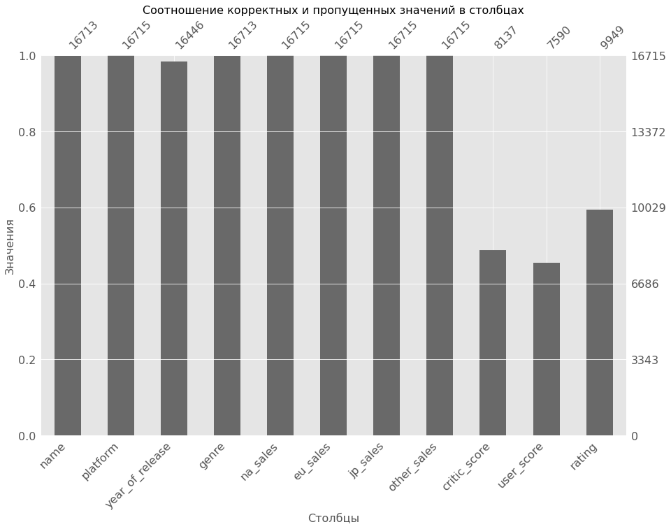

```python
#диаграмма значений
plt.style.use('ggplot')
ax = msno.bar(data, figsize=(15,10))
ax.set_title('Соотношение корректных и пропущенных значений в столбцах', fontsize=16);
ax.set_xlabel('Столбцы', fontsize=16)

ax.set_ylabel('Значения', fontsize=16)

#вывод количества пропущенных значений для каждого столбца
data.isna().sum().sort_values(ascending=False)
```

Пропуски присутствуют в следующих столбцах:

- **name**
- **year_of_release**
- **genre**
- **critic_score**
- **iser_score**
- **rating**

Причина пропусков, скорее всего, либо в том, что данные изначально не удалось получить, либо в технических проблемах при первичном вводе данных, их обработке или выгрузке.

#### Обработка пропусков в столбцах **"name"** и **"genre"**

Пропусков в столбцах почти нет: по 2 из 16715 (0.01%).

Вывод строк.

```python
data.query('name.isna()')
```

|  | name | platform | year_of_release | genre | na_sales | eu_sales | jp_sales | other_sales | critic_score | user_score | rating |
| --- | --- | --- | --- | --- | --- | --- | --- | --- | --- | --- | --- |
| 659 | NaN | GEN | 1993.0 | NaN | 1.78 | 0.53 | 0.00 | 0.08 | NaN | NaN | NaN |
| 14244 | NaN | GEN | 1993.0 | NaN | 0.00 | 0.00 | 0.03 | 0.00 | NaN | NaN | NaN |

Речь идёт о двух играх, выпущенных на платформе GEN, для которых неизвестны ни имя, ни жанр. Также для них неизвестны рейтинги. Заполнить эти пропуски, исходя из данных прочих столбцов, не представляется возможным - это можно сделать, только точно зная, о каких играх идёт речь.

Кокретные названия игр в данном случае не так важны, а вот их названия жанров необходимы для анализа, поэтому эти строки лучше удалить, учитывая, что строк всего 2 из 16715 (0,01%).

```python
data = data.dropna(subset=['name'])
```

#### Обработка пропусков в столбце "year_of_release"

Пропусков в столбцах мало: по 269 из 16713 (1.6%).

Вывод строк.

```python
data[data['year_of_release'].isna()]
```

|  | name | platform | year_of_release | genre | na_sales | eu_sales | jp_sales | other_sales | critic_score | user_score | rating |
| --- | --- | --- | --- | --- | --- | --- | --- | --- | --- | --- | --- |
| 183 | Madden NFL 2004 | PS2 | NaN | Sports | 4.26 | 0.26 | 0.01 | 0.71 | 94.0 | 8.5 | E |
| 377 | FIFA Soccer 2004 | PS2 | NaN | Sports | 0.59 | 2.36 | 0.04 | 0.51 | 84.0 | 6.4 | E |
| 456 | LEGO Batman: The Videogame | Wii | NaN | Action | 1.80 | 0.97 | 0.00 | 0.29 | 74.0 | 7.9 | E10+ |
| 475 | wwe Smackdown vs. Raw 2006 | PS2 | NaN | Fighting | 1.57 | 1.02 | 0.00 | 0.41 | NaN | NaN | NaN |
| 609 | Space Invaders | 2600 | NaN | Shooter | 2.36 | 0.14 | 0.00 | 0.03 | NaN | NaN | NaN |
| ... | ... | ... | ... | ... | ... | ... | ... | ... | ... | ... | ... |
| 16373 | PDC World Championship Darts 2008 | PSP | NaN | Sports | 0.01 | 0.00 | 0.00 | 0.00 | 43.0 | NaN | E10+ |
| 16405 | Freaky Flyers | GC | NaN | Racing | 0.01 | 0.00 | 0.00 | 0.00 | 69.0 | 6.5 | T |
| 16448 | Inversion | PC | NaN | Shooter | 0.01 | 0.00 | 0.00 | 0.00 | 59.0 | 6.7 | M |
| 16458 | Hakuouki: Shinsengumi Kitan | PS3 | NaN | Adventure | 0.01 | 0.00 | 0.00 | 0.00 | NaN | NaN | NaN |
| 16522 | Virtua Quest | GC | NaN | Role-Playing | 0.01 | 0.00 | 0.00 | 0.00 | 55.0 | 5.5 | T |

269 rows × 11 columns

Заполнить эти пропуски, исходя из данных прочих столбцов, не представляется возможным. Год выпуска игры - важный параметр, значения этого столбца понадобятся при анализе, поэтому строки с пропусками лучше удалить.

Строк с пропусками мало, и их удаление допустимо.

```python
data = data.dropna(subset=['year_of_release'])
```

#### Обработка пропусков в столбцах "critic_score" и "user_score"

Пропуски, оставшиеся после удаления строк в предыдущих столбцах и информация о датафрейме.

```python
print(data[['critic_score', 'user_score']].isna().sum(), '\n')
data.info()
```

```
critic_score    8461
user_score      8981
dtype: int64

<class 'pandas.core.frame.DataFrame'>
Int64Index: 16444 entries, 0 to 16714
Data columns (total 11 columns):
 #   Column           Non-Null Count  Dtype
---  ------           --------------  -----
 0   name             16444 non-null  object
 1   platform         16444 non-null  object
 2   year_of_release  16444 non-null  float64
 3   genre            16444 non-null  object
 4   na_sales         16444 non-null  float64
 5   eu_sales         16444 non-null  float64
 6   jp_sales         16444 non-null  float64
 7   other_sales      16444 non-null  float64
 8   critic_score     7983 non-null   float64
 9   user_score       7463 non-null   object
 10  rating           9768 non-null   object
dtypes: float64(6), object(5)
memory usage: 1.5+ MB
```

Пропусков в столбцах очень много:

- **critic_score**: 8461 из 16444 (51,5%);
- **user_score**: 8981 из 16444 (54,6%);

Удалять эти строки нельзя - их слишком много, и данные в других столбцах выглядят корректно и наверняка понадобятся для анализа. Также нельзя заполнять такое большое количество значений, к примеру, медианным или средним значением, потому что это вызовет слишком болшьшие искажения данных.

Поэтому заполним пропуски в обоих столбцах заглушкой со значением "-1" и исключим их при анализе данных по этим столбцам.

```python
#замена
data[['critic_score','user_score']] = data[['critic_score','user_score']].fillna(-1)

#проверка
data.query(
    'critic_score.isna() | \
    user_score.isna()'
).shape
```

```
(0, 11)
```

#### Обработка пропусков в столбце "rating"

Пропусков в столбце очень много: **rating**: 6766 из 16715 (40,5%). Помимо технических проблем и ошибок, причиной возникновения пропусков может быть изначальное отсутствие данных: игры могли быть не оценены агентством ESRB либо оценки оказались недоступны. В любом случае, удалять такое большое количество строк нельзя, а заполнить эти пропуски без доступа к базе данных ESRB невозможно.

Также агентство ESRB занимается определением рейтингов для компьютерных видеоигр и другого развлекательного программного обеспечения в США и Канаде, а значит, пропуски могут относиться к играм, которые выходили в других регионах и не были локализованы для североамериканского региона.

Поэтому эти пропуски нужно оставить и заменить значением **unknown** для всех регионов, кроме Северной Америки: здесь пропуски, по-видимому, означают отсутствие данных

```python
data.loc[data['na_sales'] == 0, 'rating'] = data.loc[data['na_sales'] == 0, 'rating'].fillna('unknown')
```

#### Оставшиеся в столбцах пропуски.

```
rating             2988
name                  0
platform              0
year_of_release       0
genre                 0
na_sales              0
eu_sales              0
jp_sales              0
other_sales           0
critic_score          0
user_score            0
dtype: int64
```

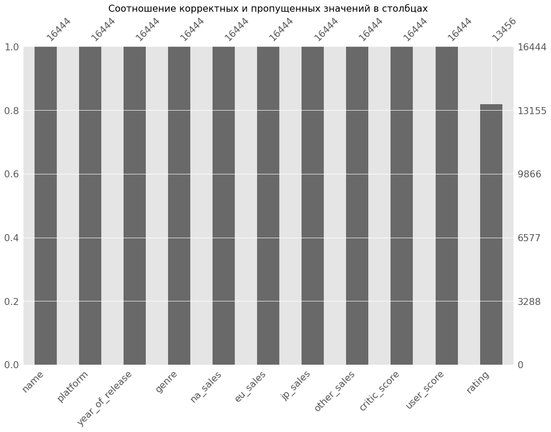

```python
#диаграмма значений
msno.bar(data, figsize=(15,10))
plt.title('Соотношение корректных и пропущенных значений в столбцах', fontsize=16);

#вывод количества пропущенных значений для каждого столбца
data.isna().sum().sort_values(ascending=False)
```

### Преобразование типов данных

Приведение типов данных:

- **year_of_release** - к типу int для оптимизации обработки, поскольку в столбце целочисленные значения. Приведение значений данного столбца к типу даты pandas нецелесообразно, потому что обрабатывать их как datetime не понадобится, а как числовые значения - да;
- **critic_score** - к типу int для оптимизации обработки, поскольку в столбце целочисленные значения.
- **user_score** к типу float, поскольку в столбце хранятся числовые значения.

```python
#приведение к типам
data[['year_of_release',
    'critic_score']] = data[['year_of_release',
                             'critic_score']].astype(int)

#приведение столбца user_score к типу float
data['user_score'] = data['user_score'].astype(float)

#проверка
data.dtypes
```

```
name                object
platform            object
year_of_release      int32
genre               object
na_sales           float64
eu_sales           float64
jp_sales           float64
other_sales        float64
critic_score         int32
user_score         float64
rating              object
dtype: object
```

Значения столбцов приведены к необходимым типам.

### Обработка дубликатов

Проверка на явные дубликаты строк.

```python
data.duplicated().sum()
```

```
0
```

Явные дубликаты отстутствуют.

Необходимо проверить на неявные дубликаты следующие столбцы:

- **name**
- **platform**
- **genre**
- **rating**

#### Столбец **name**

Список значений столбца.

```python
data['name'].value_counts()
```

```
Need for Speed: Most Wanted    12
Ratatouille                     9
FIFA 14                         9
LEGO Marvel Super Heroes        9
Madden NFL 08                   8
                               ..
Imagine: Rock Star              1
Highschool Terra Story          1
The House of the Dead 2         1
SD Gundam G Generation          1
Jampack Volume 13 (RP-T)        1
Name: name, Length: 11426, dtype: int64
```

Многие названия повторяются. Выведем на экран строки с наиболее частым значением:

```python
data[data['name'] == 'Need for Speed: Most Wanted']
```

|  | name | platform | year_of_release | genre | na_sales | eu_sales | jp_sales | other_sales | critic_score | user_score | rating |
| --- | --- | --- | --- | --- | --- | --- | --- | --- | --- | --- | --- |
| 253 | Need for Speed: Most Wanted | PS2 | 2005 | Racing | 2.03 | 1.79 | 0.08 | 0.47 | 82 | 9.1 | T |
| 523 | Need for Speed: Most Wanted | PS3 | 2012 | Racing | 0.71 | 1.46 | 0.06 | 0.58 | -1 | -1.0 | NaN |
| 1190 | Need for Speed: Most Wanted | X360 | 2012 | Racing | 0.62 | 0.78 | 0.01 | 0.15 | 83 | 8.5 | T |
| 1591 | Need for Speed: Most Wanted | X360 | 2005 | Racing | 1.00 | 0.13 | 0.02 | 0.10 | 83 | 8.5 | T |
| 1998 | Need for Speed: Most Wanted | XB | 2005 | Racing | 0.53 | 0.46 | 0.00 | 0.05 | 83 | 8.8 | T |
| 2048 | Need for Speed: Most Wanted | PSV | 2012 | Racing | 0.33 | 0.45 | 0.01 | 0.22 | -1 | -1.0 | NaN |
| 3581 | Need for Speed: Most Wanted | GC | 2005 | Racing | 0.43 | 0.11 | 0.00 | 0.02 | 80 | 9.1 | T |
| 5972 | Need for Speed: Most Wanted | PC | 2005 | Racing | 0.02 | 0.23 | 0.00 | 0.04 | 82 | 8.5 | T |
| 6273 | Need for Speed: Most Wanted | WiiU | 2013 | Racing | 0.13 | 0.12 | 0.00 | 0.02 | -1 | -1.0 | NaN |
| 6410 | Need for Speed: Most Wanted | DS | 2005 | Racing | 0.24 | 0.01 | 0.00 | 0.02 | 45 | 6.1 | E |
| 6473 | Need for Speed: Most Wanted | GBA | 2005 | Racing | 0.19 | 0.07 | 0.00 | 0.00 | -1 | 8.3 | E |
| 11715 | Need for Speed: Most Wanted | PC | 2012 | Racing | 0.00 | 0.06 | 0.00 | 0.02 | 82 | 8.5 | T |

Игры, выпущенные для разных консолей считаются разными играми. То же самое можно сказать и о перезапусках популярных игр в разные годы.

Поэтому для игры "Need for Speed: Most Wanted" дубликатов на самом деле нет.

Чтобы проверить на дубликаты названий этот столбец, нужно найти строки, для которых совпадают название, платформа и год выпуска игры. В случаях, когда такой набор будет совпадать, можно будет подозревать дублирование информации.

```python
data[data[['name', 'platform','year_of_release']].duplicated(keep=False)]
```

|  | name | platform | year_of_release | genre | na_sales | eu_sales | jp_sales | other_sales | critic_score | user_score | rating |
| --- | --- | --- | --- | --- | --- | --- | --- | --- | --- | --- | --- |
| 604 | Madden NFL 13 | PS3 | 2012 | Sports | 2.11 | 0.22 | 0.0 | 0.23 | 83 | 5.5 | E |
| 16230 | Madden NFL 13 | PS3 | 2012 | Sports | 0.00 | 0.01 | 0.0 | 0.00 | 83 | 5.5 | E |

Для данных строк совпадает всё, кроме показателей выручки. Очевидно, игру либо внесли в таблицу дважды, либо дубликат строки возник при обработке данных - к примеру, при объединении таблиц из разных источников. Полагаю, что строка 16230 является дубликатом (значения выручки почти нулевые), и её нужно удалить.

```python
data = data.drop(index=16230)
```

#### Столбец "platform"

Список значений столбца и их количество.

```python
data['platform'].value_counts()
```

```
PS2     2127
DS      2121
PS3     1305
Wii     1286
X360    1232
PSP     1193
PS      1190
PC       957
GBA      811
XB       803
GC       542
3DS      512
PSV      429
PS4      392
N64      316
XOne     247
SNES     239
SAT      173
WiiU     147
2600     116
NES       98
GB        97
DC        52
GEN       27
NG        12
WS         6
SCD        6
3DO        3
TG16       2
PCFX       1
GG         1
Name: platform, dtype: int64
```

Все значения уникальны и соответствуют названиям игровых платформ (информация из открытых источников). Дубликатов нет.

#### Столбец "genre"

Список значений столбца и их количество.

```python
data['genre'].value_counts()
```

```
Action          3307
Sports          2305
Misc            1721
Role-Playing    1481
Shooter         1296
Adventure       1293
Racing          1226
Platform         878
Simulation       857
Fighting         837
Strategy         673
Puzzle           569
Name: genre, dtype: int64
```

Все значения уникальны и соответствуют названиям жанров игр (информация из открытых источников). Дубликатов нет.

#### Столбец "rating"

Список значений столбца и их количество.

```python
data['rating'].value_counts()
```

```
E          3920
unknown    3688
T          2905
M          1536
E10+       1393
EC            8
K-A           3
RP            1
AO            1
Name: rating, dtype: int64
```

Все значения уникальны и соответствуют обозначениям рейтингов ESRB (информация из открытых источников). Дубликатов нет.

### Добавление столбца "total_sales", содержащего суммарные продажи во всех регионах

```python
#для удобства поместим колонку сразу после столбца 'other_sales'
data.insert(
    loc=data.columns.get_loc('other_sales')+1,
    column = 'total_sales',
    value=data.loc[:,['na_sales','eu_sales', 'jp_sales', 'other_sales']].sum(axis=1)
    )

#вывод датафрейма с новым столбцом
data
```

|  | name | platform | year_of_release | genre | na_sales | eu_sales | jp_sales | other_sales | total_sales | critic_score | user_score | rating |
| --- | --- | --- | --- | --- | --- | --- | --- | --- | --- | --- | --- | --- |
| 0 | Wii Sports | Wii | 2006 | Sports | 41.36 | 28.96 | 3.77 | 8.45 | 82.54 | 76 | 8.0 | E |
| 1 | Super Mario Bros. | NES | 1985 | Platform | 29.08 | 3.58 | 6.81 | 0.77 | 40.24 | -1 | -1.0 | NaN |
| 2 | Mario Kart Wii | Wii | 2008 | Racing | 15.68 | 12.76 | 3.79 | 3.29 | 35.52 | 82 | 8.3 | E |
| 3 | Wii Sports Resort | Wii | 2009 | Sports | 15.61 | 10.93 | 3.28 | 2.95 | 32.77 | 80 | 8.0 | E |
| 4 | Pokemon Red/Pokemon Blue | GB | 1996 | Role-Playing | 11.27 | 8.89 | 10.22 | 1.00 | 31.38 | -1 | -1.0 | NaN |
| ... | ... | ... | ... | ... | ... | ... | ... | ... | ... | ... | ... | ... |
| 16710 | Samurai Warriors: Sanada Maru | PS3 | 2016 | Action | 0.00 | 0.00 | 0.01 | 0.00 | 0.01 | -1 | -1.0 | unknown |
| 16711 | LMA Manager 2007 | X360 | 2006 | Sports | 0.00 | 0.01 | 0.00 | 0.00 | 0.01 | -1 | -1.0 | unknown |
| 16712 | Haitaka no Psychedelica | PSV | 2016 | Adventure | 0.00 | 0.00 | 0.01 | 0.00 | 0.01 | -1 | -1.0 | unknown |
| 16713 | Spirits & Spells | GBA | 2003 | Platform | 0.01 | 0.00 | 0.00 | 0.00 | 0.01 | -1 | -1.0 | NaN |
| 16714 | Winning Post 8 2016 | PSV | 2016 | Simulation | 0.00 | 0.00 | 0.01 | 0.00 | 0.01 | -1 | -1.0 | unknown |

16443 rows × 12 columns

### Вывод по результатам предобработки данных

Названия столбцов датафрейма приведены к нижнему регистру.

В столбце **user_score** значения "**tbd**" приняты за пропуски.

Явных дубликатов строк нет. Обнаруженный неявный дубликат удалён.

Столбцы **year_of_release** и **critic_score** приведены к типу **int**, столбец **user_score** к типу **float**.

В датафрейм добален столбец **total_sales**, содержащий суммарные продажи во всех регионах.

## Исследовательский анализ данных

### Количество игр, выпущенных в разные годы.

```python
#создание сводной таблицы
pivot_year = (data.query('year_of_release != 0') #удаление строк с пропусками, заменёнными на нули
              .pivot_table(
                index='year_of_release',
                values='name', aggfunc='count'
                )
             )


#вывод
pivot_year
```

| year_of_release | name |
| --- | --- |
| 1980 | 9 |
| 1981 | 46 |
| 1982 | 36 |
| 1983 | 17 |
| 1984 | 14 |
| 1985 | 14 |
| 1986 | 21 |
| 1987 | 16 |
| 1988 | 15 |
| 1989 | 17 |
| 1990 | 16 |
| 1991 | 41 |
| 1992 | 43 |
| 1993 | 60 |
| 1994 | 121 |
| 1995 | 219 |
| 1996 | 263 |
| 1997 | 289 |
| 1998 | 379 |
| 1999 | 338 |
| 2000 | 350 |
| 2001 | 482 |
| 2002 | 829 |
| 2003 | 775 |
| 2004 | 762 |
| 2005 | 939 |
| 2006 | 1006 |
| 2007 | 1197 |
| 2008 | 1427 |
| 2009 | 1426 |
| 2010 | 1255 |
| 2011 | 1136 |
| 2012 | 652 |
| 2013 | 544 |
| 2014 | 581 |
| 2015 | 606 |
| 2016 | 502 |

Отображение в качестве графика.

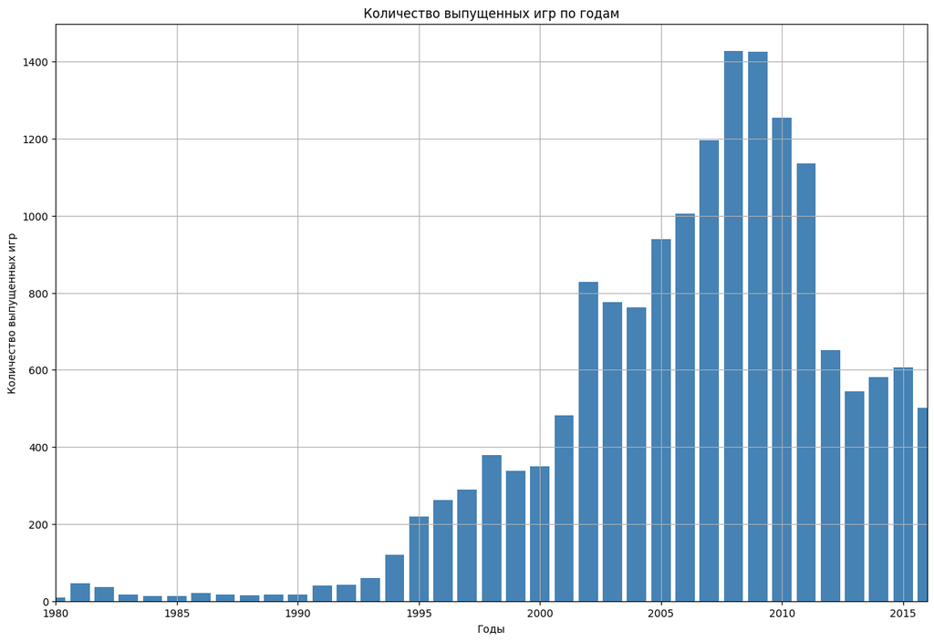

```python
plt.style.use('default')
#построение графика
plt.figure(figsize=(15,10))
plt.xlim(1980, 2016)
plt.bar(pivot_year.index, pivot_year['name'], color='steelblue');
plt.grid(True)
plt.ylabel('Количество выпущенных игр')
plt.xlabel('Годы')
plt.title('Количество выпущенных игр по годам')
plt.show()
```

С 1980 по 1992 годы выпускали скромное по современным меркам количество игр. В начале 1980-х был небольшой бум выпуска игр, который сошёл на нет к 1990 году. Начиная с 1991 года наблюдается рост количествоа выпущенных игр, который с небольшими перерывами в 1999-2000 и 2002-2003 годах продолжался до максимума в 2008-2009 годах, а затем пошёл на спад, вероятно, сказался мировой экономический кризис 2008 года. Начиная с 2012 года количество выпущенных игр распределено сравнительно равномерно.

### Изменение продаж с течением времени для различных платформ

Сводная таблица суммарных продаж для разных платформ.

```python
#сводная таблица
pivot_platform_sales = (
    data.pivot_table(
    index='platform',
    values='total_sales',
    aggfunc='sum')
 .sort_values(
     by='total_sales')
)

pivot_platform_sales
```

| platform | total_sales |
| --- | --- |
| PCFX | 0.03 |
| GG | 0.04 |
| 3DO | 0.10 |
| TG16 | 0.16 |
| WS | 1.42 |
| NG | 1.44 |
| SCD | 1.86 |
| DC | 15.95 |
| GEN | 28.35 |
| SAT | 33.59 |
| PSV | 53.81 |
| WiiU | 82.19 |
| 2600 | 86.48 |
| XOne | 159.32 |
| GC | 196.73 |
| SNES | 200.04 |
| N64 | 218.01 |
| NES | 251.05 |
| XB | 251.57 |
| GB | 254.43 |
| PC | 255.76 |
| 3DS | 257.81 |
| PSP | 289.53 |
| GBA | 312.88 |
| PS4 | 314.14 |
| PS | 727.58 |
| DS | 802.78 |
| Wii | 891.18 |
| PS3 | 931.33 |
| X360 | 961.24 |
| PS2 | 1233.56 |

Отображение в качестве графика.

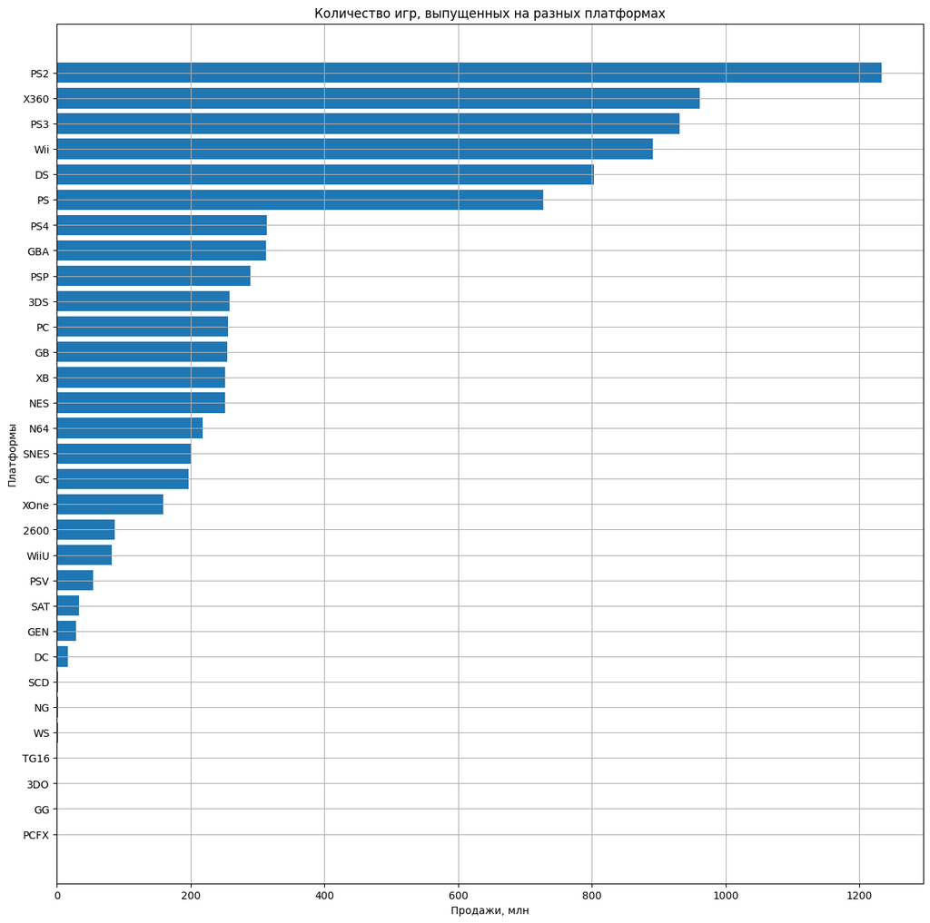

```python
#построение графика
plt.figure(figsize=(15,15))
plt.barh(pivot_platform_sales.index, pivot_platform_sales['total_sales']);
plt.grid(True)
plt.ylabel('Платформы')
plt.xlabel('Продажи, млн')
plt.title('Количество игр, выпущенных на разных платформах')
plt.show()
```

- **PS2**
- **X360**
- **PS3**
- **Wii**
- **DS**
- **PS**

```python
#создание сводной таблицы
pivot_top_platform = (
    data
        .query('platform == ["PS2", "X360", "PS3", "Wii", "DS", "PS"]')
        .pivot_table(
            index=['platform', 'year_of_release'],
            values='total_sales',
            aggfunc='sum')
        .reset_index()
)

#вывод
pivot_top_platform
```

|  | platform | year_of_release | total_sales |
| --- | --- | --- | --- |
| 0 | DS | 1985 | 0.02 |
| 1 | DS | 2004 | 17.27 |
| 2 | DS | 2005 | 130.14 |
| 3 | DS | 2006 | 119.81 |
| 4 | DS | 2007 | 146.94 |
| ... | ... | ... | ... |
| 62 | X360 | 2012 | 99.74 |
| 63 | X360 | 2013 | 88.58 |
| 64 | X360 | 2014 | 34.74 |
| 65 | X360 | 2015 | 11.96 |
| 66 | X360 | 2016 | 1.52 |

67 rows × 3 columns

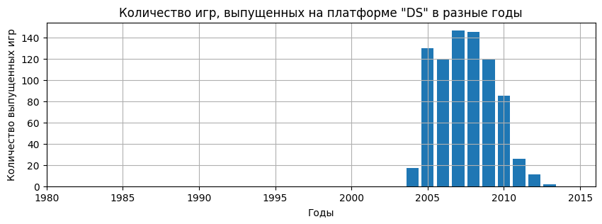

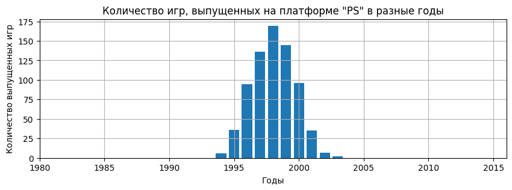

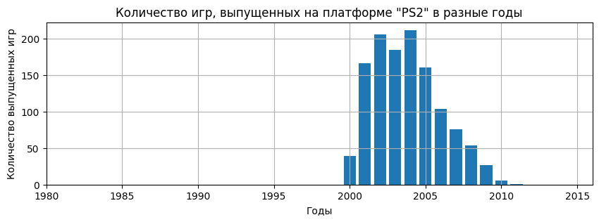

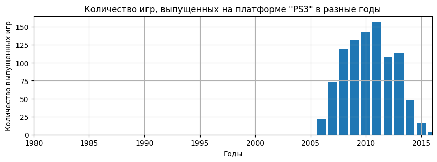

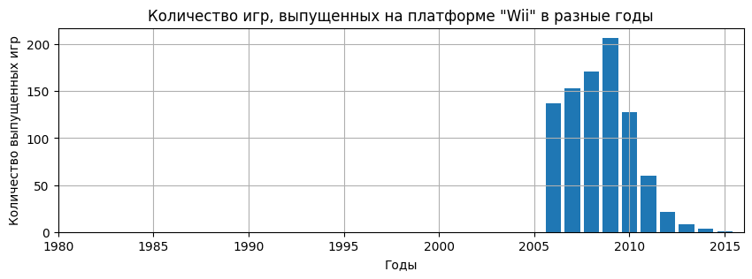

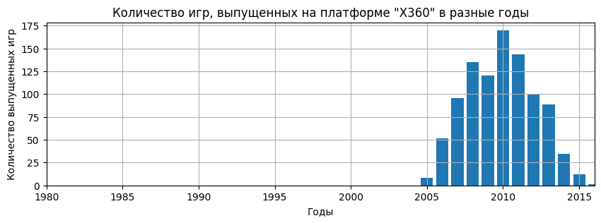

```python
for plat in pivot_top_platform['platform'].unique():
    plt.figure(figsize=(10,3))
    plt.xlim(1980, 2016)
    plt.bar(
        pivot_top_platform.query('platform == @plat')['year_of_release'],
        pivot_top_platform.query('platform == @plat')['total_sales']);
    plt.grid(True)
    plt.ylabel('Количество выпущенных игр')
    plt.xlabel('Годы')
    plt.title(f'Количество игр, выпущенных на платформе "{plat}" в разные годы')
    plt.show()
```

Характерный период жизни платформы составляет 10-11 лет.

### Выбор актульного периода.

Наиболее подходящим для анализа выглядит период 2014-2016 годов, поскольку это наиболее близкий к 2017 году период с относительно стабильной тенденцией количества выпущенных игр.

```python
#создание датафрейма с данными за 2014-2016 годы
data_act = data.query('2013 < year_of_release').reset_index(drop=True)

#вывод
data_act
```

|  | name | platform | year_of_release | genre | na_sales | eu_sales | jp_sales | other_sales | total_sales | critic_score | user_score | rating |
| --- | --- | --- | --- | --- | --- | --- | --- | --- | --- | --- | --- | --- |
| 0 | Call of Duty: Black Ops 3 | PS4 | 2015 | Shooter | 6.03 | 5.86 | 0.36 | 2.38 | 14.63 | -1 | -1.0 | NaN |
| 1 | Grand Theft Auto V | PS4 | 2014 | Action | 3.96 | 6.31 | 0.38 | 1.97 | 12.62 | 97 | 8.3 | M |
| 2 | Pokemon Omega Ruby/Pokemon Alpha Sapphire | 3DS | 2014 | Role-Playing | 4.35 | 3.49 | 3.10 | 0.74 | 11.68 | -1 | -1.0 | NaN |
| 3 | FIFA 16 | PS4 | 2015 | Sports | 1.12 | 6.12 | 0.06 | 1.28 | 8.58 | 82 | 4.3 | E |
| 4 | Star Wars Battlefront (2015) | PS4 | 2015 | Shooter | 2.99 | 3.49 | 0.22 | 1.28 | 7.98 | -1 | -1.0 | NaN |
| ... | ... | ... | ... | ... | ... | ... | ... | ... | ... | ... | ... | ... |
| 1684 | Strawberry Nauts | PSV | 2016 | Adventure | 0.00 | 0.00 | 0.01 | 0.00 | 0.01 | -1 | -1.0 | unknown |
| 1685 | Aiyoku no Eustia | PSV | 2014 | Misc | 0.00 | 0.00 | 0.01 | 0.00 | 0.01 | -1 | -1.0 | unknown |
| 1686 | Samurai Warriors: Sanada Maru | PS3 | 2016 | Action | 0.00 | 0.00 | 0.01 | 0.00 | 0.01 | -1 | -1.0 | unknown |
| 1687 | Haitaka no Psychedelica | PSV | 2016 | Adventure | 0.00 | 0.00 | 0.01 | 0.00 | 0.01 | -1 | -1.0 | unknown |
| 1688 | Winning Post 8 2016 | PSV | 2016 | Simulation | 0.00 | 0.00 | 0.01 | 0.00 | 0.01 | -1 | -1.0 | unknown |

1689 rows × 12 columns

Общие данные плученного датафрейма.

```python
data_act.info()
```

```
<class 'pandas.core.frame.DataFrame'>
RangeIndex: 1689 entries, 0 to 1688
Data columns (total 12 columns):
 #   Column           Non-Null Count  Dtype
---  ------           --------------  -----
 0   name             1689 non-null   object
 1   platform         1689 non-null   object
 2   year_of_release  1689 non-null   int32
 3   genre            1689 non-null   object
 4   na_sales         1689 non-null   float64
 5   eu_sales         1689 non-null   float64
 6   jp_sales         1689 non-null   float64
 7   other_sales      1689 non-null   float64
 8   total_sales      1689 non-null   float64
 9   critic_score     1689 non-null   int32
 10  user_score       1689 non-null   float64
 11  rating           1455 non-null   object
dtypes: float64(6), int32(2), object(4)
memory usage: 145.3+ KB
```

### Выбор потенциально прибыльных платформ

Платформы, лидирующие по продажам.

```python
#сводная таблица
pivot_platform_sales_act = (
    data_act.pivot_table(
    index='platform',
    values='total_sales',
    aggfunc='sum')
 .sort_values(
     by='total_sales')
)

pivot_platform_sales_act
```

| platform | total_sales |
| --- | --- |
| PSP | 0.36 |
| Wii | 5.07 |
| PSV | 22.40 |
| PC | 27.05 |
| WiiU | 42.98 |
| X360 | 48.22 |
| PS3 | 68.18 |
| 3DS | 86.68 |
| XOne | 140.36 |
| PS4 | 288.15 |

Отображение в виде графика.

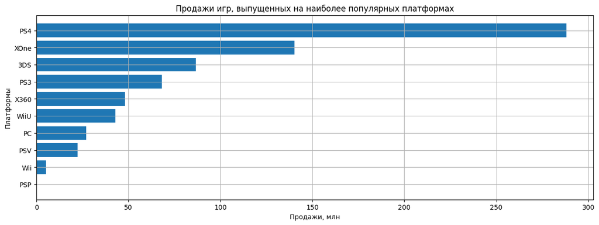

```python
#построение графика
plt.figure(figsize=(15,5))
plt.barh(pivot_platform_sales_act.index, pivot_platform_sales_act['total_sales']);
plt.grid(True)
plt.ylabel('Платформы')
plt.xlabel('Продажи, млн')
plt.title('Продажи игр, выпущенных на наиболее популярных платформах')
plt.show()
```

За выбранный период (2014-2016 годы) есть данные о 10 платформах. Наибольшие продажи демонстрируют 5 из них:

- **PS4**
- **XOne**
- **3DS**
- **PS3**
- **X360**

Платформа **PS4** лидирует с большим отрывом.

### Динамика глобальных продаж различных платформ

```python
#создание сводной таблицы
pivot_platform_sales_act = (
    data_act
        .pivot_table(
            index=['platform', 'year_of_release'],
            values='total_sales',
            aggfunc='sum')
        .reset_index()
        .set_index('year_of_release')
)

#вывод
pivot_platform_sales_act
```

| year_of_release | platform | total_sales |
| --- | --- | --- |
| 2014 | 3DS | 43.76 |
| 2015 | 3DS | 27.78 |
| 2016 | 3DS | 15.14 |
| 2014 | PC | 13.28 |
| 2015 | PC | 8.52 |
| 2016 | PC | 5.25 |
| 2014 | PS3 | 47.76 |
| 2015 | PS3 | 16.82 |
| 2016 | PS3 | 3.60 |
| 2014 | PS4 | 100.00 |
| 2015 | PS4 | 118.90 |
| 2016 | PS4 | 69.25 |
| 2014 | PSP | 0.24 |
| 2015 | PSP | 0.12 |
| 2014 | PSV | 11.90 |
| 2015 | PSV | 6.25 |
| 2016 | PSV | 4.25 |
| 2014 | Wii | 3.75 |
| 2015 | Wii | 1.14 |
| 2016 | Wii | 0.18 |
| 2014 | WiiU | 22.03 |
| 2015 | WiiU | 16.35 |
| 2016 | WiiU | 4.60 |
| 2014 | X360 | 34.74 |
| 2015 | X360 | 11.96 |
| 2016 | X360 | 1.52 |
| 2014 | XOne | 54.07 |
| 2015 | XOne | 60.14 |
| 2016 | XOne | 26.15 |

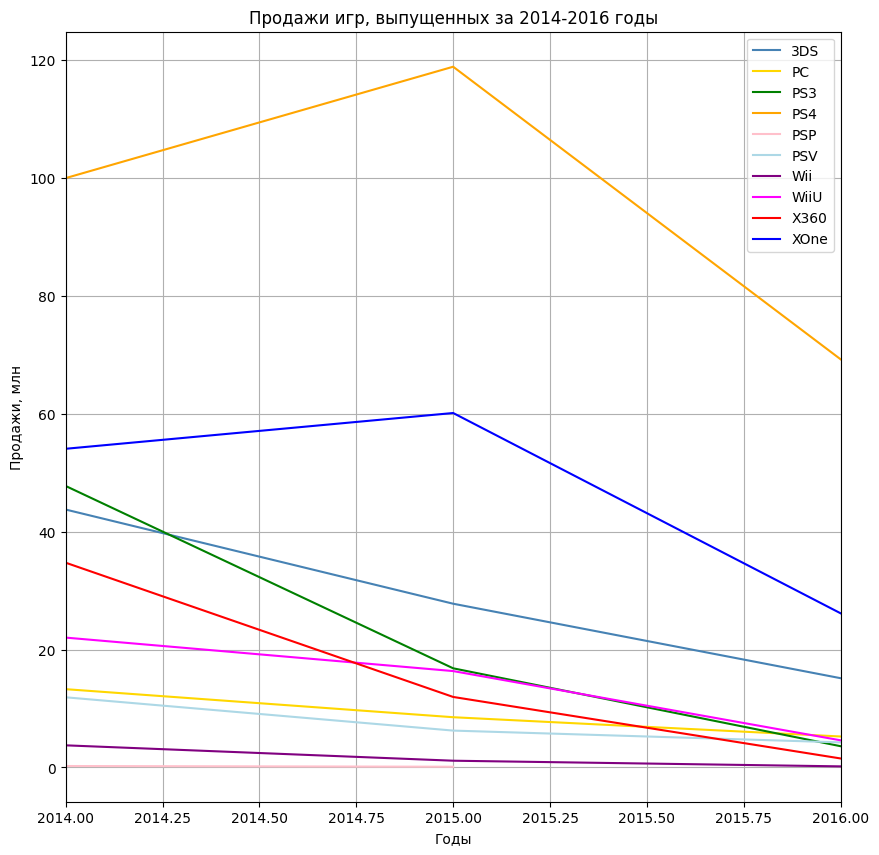

```python
#выбор цветовой схемы
colors=[
    'steelblue',
    'gold',
    'green',
    'orange',
    'pink',
    'lightblue',
    'purple',
    'magenta',
    'red',
    'blue',
    'brown',
    'grey']
i = 0
legend=[]

#построение графика
plt.figure(figsize=(10,10))
for plat in pivot_platform_sales_act['platform'].unique():
    (pivot_platform_sales_act
     .query('platform == @plat')['total_sales']
     .plot(color=colors[i])
    )
    i += 1
    legend.append(plat)
plt.legend(legend);
plt.grid(True)
plt.ylabel('Продажи, млн')
plt.xlabel('Годы')
plt.xlim(2014, 2016)
plt.title(f'Продажи игр, выпущенных за 2014-2016 годы');
```

По объёмам продаж лидируют следующие платформы:

- **PS4**
- **XOne**
- **3DS**

### Диаграммы размаха глобальных продаж в разбивке по платформам

Построение диаграмм размаха.

```
count    1689.000000
mean        0.431883
std         1.056109
min         0.010000
25%         0.030000
50%         0.100000
75%         0.350000
max        14.630000
Name: total_sales, dtype: float64
```

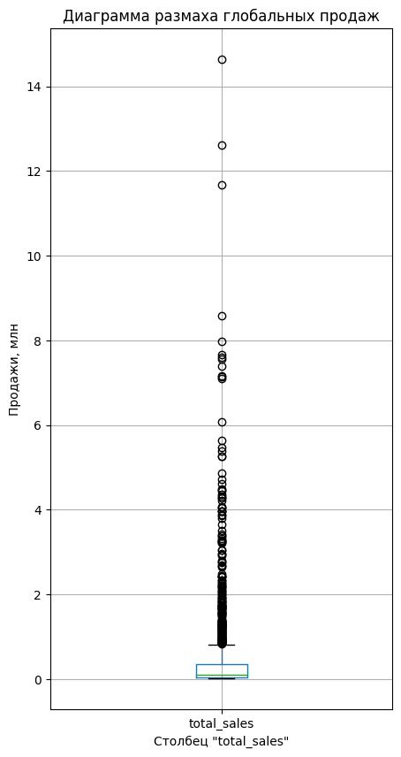

```python
#диаграмма размаха
data_act.boxplot('total_sales', figsize=(5,10));
plt.xlabel('Столбец "total_sales"')
plt.ylabel('Продажи, млн')
plt.title('Диаграмма размаха глобальных продаж')


#общие характеристики
data_act['total_sales'].describe()
```

В диаграмме большой разброс значений, которые отображены как аномально большие. Максимальное значение в столбце 14.63 млн и среднее 0,43 млн при медианном 0,1 млн.

Изучим часть датафрейма с "аномально большими" продажами.

```python
data_act.query('total_sales > 1.6')
```

|  | name | platform | year_of_release | genre | na_sales | eu_sales | jp_sales | other_sales | total_sales | critic_score | user_score | rating |
| --- | --- | --- | --- | --- | --- | --- | --- | --- | --- | --- | --- | --- |
| 0 | Call of Duty: Black Ops 3 | PS4 | 2015 | Shooter | 6.03 | 5.86 | 0.36 | 2.38 | 14.63 | -1 | -1.0 | NaN |
| 1 | Grand Theft Auto V | PS4 | 2014 | Action | 3.96 | 6.31 | 0.38 | 1.97 | 12.62 | 97 | 8.3 | M |
| 2 | Pokemon Omega Ruby/Pokemon Alpha Sapphire | 3DS | 2014 | Role-Playing | 4.35 | 3.49 | 3.10 | 0.74 | 11.68 | -1 | -1.0 | NaN |
| 3 | FIFA 16 | PS4 | 2015 | Sports | 1.12 | 6.12 | 0.06 | 1.28 | 8.58 | 82 | 4.3 | E |
| 4 | Star Wars Battlefront (2015) | PS4 | 2015 | Shooter | 2.99 | 3.49 | 0.22 | 1.28 | 7.98 | -1 | -1.0 | NaN |
| ... | ... | ... | ... | ... | ... | ... | ... | ... | ... | ... | ... | ... |
| 103 | Until Dawn | PS4 | 2015 | Adventure | 0.45 | 0.90 | 0.05 | 0.26 | 1.66 | 79 | 8.2 | M |
| 104 | Dark Souls III | PS4 | 2016 | Role-Playing | 0.65 | 0.45 | 0.34 | 0.22 | 1.66 | 89 | 8.8 | M |
| 105 | Far Cry 4 | XOne | 2014 | Shooter | 0.80 | 0.69 | 0.01 | 0.14 | 1.64 | 82 | 7.5 | M |
| 106 | NBA 2K15 | X360 | 2014 | Sports | 1.35 | 0.11 | 0.00 | 0.17 | 1.63 | -1 | 3.0 | E |
| 107 | Destiny | PS3 | 2014 | Shooter | 0.68 | 0.56 | 0.12 | 0.25 | 1.61 | -1 | 4.5 | T |

108 rows × 12 columns

```python
#количество и сумма продаж самых популярных игр
print(
    'Количество самых популярных игр:',
    '\n',
    data_act.query('total_sales > 1.6')['total_sales'].count(),
    '\n',
    '\n',
    'Сумма продаж самых популярных игр:',
    '\n',
    data_act.query('total_sales > 1.6')['total_sales'].sum()
)
```

```
Количество самых популярных игр:
 108

 Сумма продаж самых популярных игр:
 389.07
```

```python
#количество и сумма продаж большинства менее популярных игр
print(
    'Количество менее популярных игр:',
    '\n',
    data_act.query('total_sales < 1.6')['total_sales'].count(),
    '\n',
    '\n',
    'Сумма продаж менее популярных игр:',
    '\n',
    data_act.query('total_sales < 1.6')['total_sales'].sum()
)
```

```
Количество менее популярных игр:
 1581

 Сумма продаж менее популярных игр:
 340.38
```

Очевидно, это не аномальные значения, а особенность распределения значений в стобце: наиболее популярные игры редки, а основную массу составляют игры, чьи продажи уступают лидерам в разы или даже на порядки. При этом суммарные продажи первых выше вторых.

Ниже построены диаграммы размаха для глобальных продаж в разбивке по платформам в двух вариантах:

- для всех игр;
- для основной массы менее популярных игр.

```
(0.0, 1.6)
```

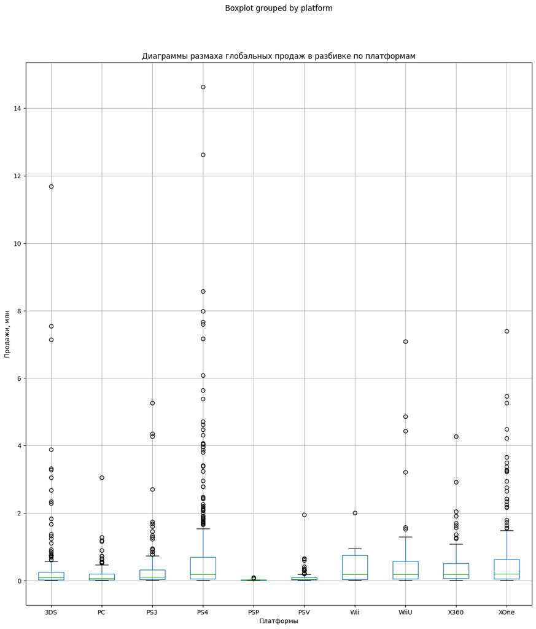

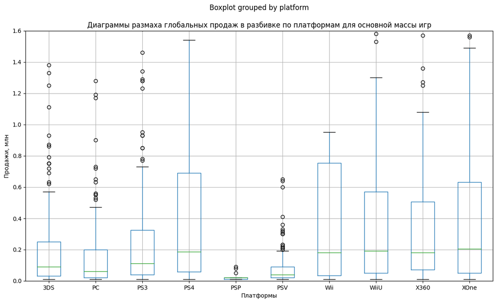

```python
data_act.sort_values(by='total_sales').boxplot('total_sales', 'platform', figsize=(14,16));
plt.title('Диаграммы размаха глобальных продаж в разбивке по платформам')
plt.xlabel('Платформы')
plt.ylabel('Продажи, млн');

data_act.boxplot('total_sales', 'platform', figsize=(14,8));
plt.title('Диаграммы размаха глобальных продаж в разбивке по платформам для основной массы игр')
plt.xlabel('Платформы')
plt.ylabel('Продажи, млн');
plt.ylim(0, 1.6)
```

Для каждой из рассматриваемых платформ есть относительно небольшое количество популярных игр и гораздо большая основная масса игр, притом суммарные продажи немногочисленных игр-лидеров сравнимы и могут даже превышать суммарные продажи большинства менее популярных игр.

### Влияние отзывов пользователей и критиков на продажи

```python
data_critic = data_act.query('critic_score != -1')
data_user = data_act.query('user_score != -1')
```

#### Влияние отзывов критиков на продажи игр, выпущенных для пяти наиболее популярных платформ

Коэффициенты корелляции и диаграммы рассеяния.

```
Коэффициент корелляции между продажами и отзывами критиков для платформы PS4: 0.4019028781147529


Коэффициент корелляции между продажами и отзывами критиков для платформы XOne: 0.4221118510555763


Коэффициент корелляции между продажами и отзывами критиков для платформы WiiU: 0.3756402218389979


Коэффициент корелляции между продажами и отзывами критиков для платформы 3DS: 0.28468579095782925


Коэффициент корелляции между продажами и отзывами критиков для платформы PC: 0.17206091490145103
```

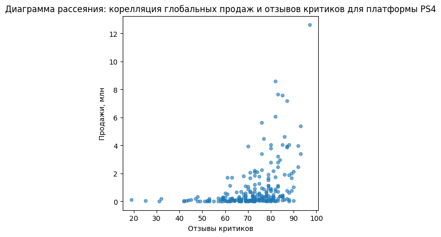

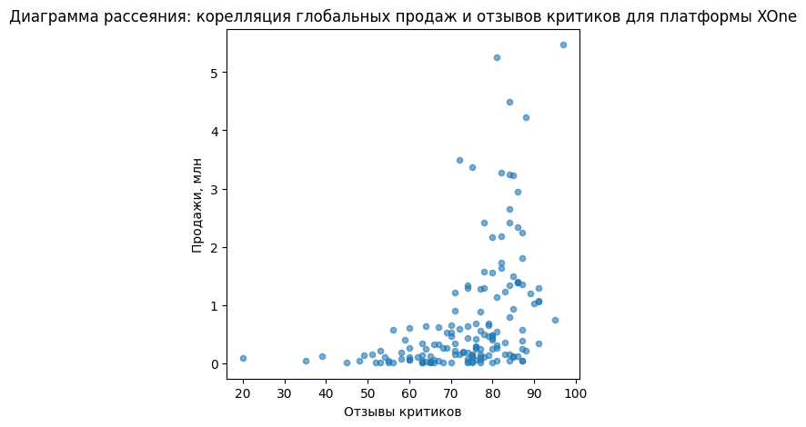

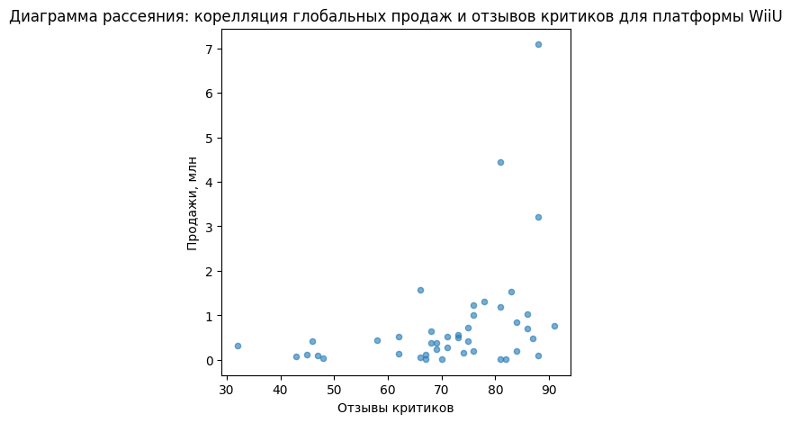

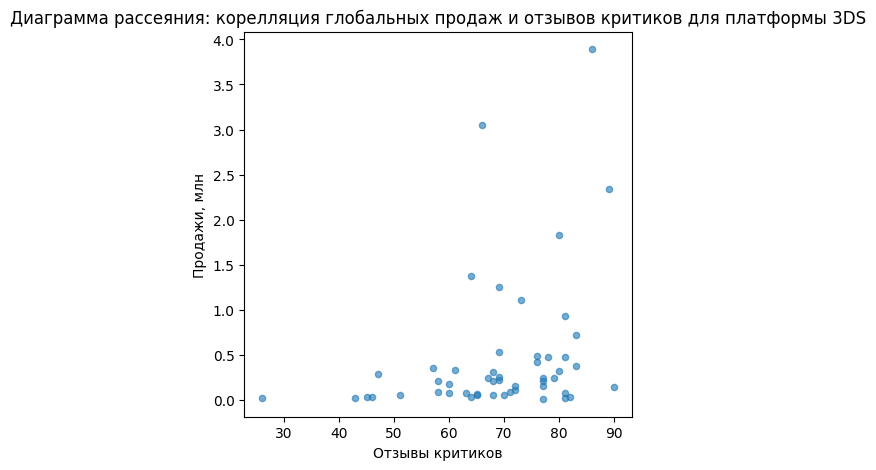

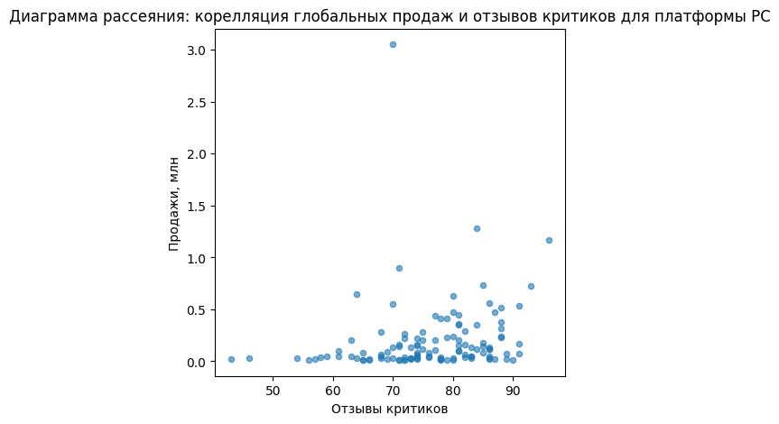

```python
for plat in (data_critic
             .groupby('platform')['total_sales']
             .agg('sum')
             .sort_values(ascending=False)
             .head()
             .index
            ):
    #коэффициент корелляции
    print(f'Коэффициент корелляции между продажами и отзывами критиков для платформы {plat}:',
      (data_critic
       .query('platform == @plat')['total_sales']
       .corr(data_user.query('platform == @plat')['critic_score'])
      ),  '\n', '\n'
     )

    #диаграмма рассеяния
    (data_critic
     .query('platform == @plat')
     .plot(kind='scatter', x='critic_score', y='total_sales', alpha=0.6, figsize=(5, 5))
    )
    plt.title(f'Диаграмма рассеяния: корелляция глобальных продаж и отзывов критиков для платформы {plat}')
    plt.xlabel('Отзывы критиков')
    plt.ylabel('Продажи, млн');
```

Корелляция для всех платформ слабая, а диаграммы рассеивания демонстрируют, что, несмотря на редкие исключения, высокие отзывы критиков как правило не означают хорошие продажи, и наоборот.

#### Влияние отзывов пользователей на продажи игр, выпущенных для для пяти наиболее популярных платформ

Коэффициент корелляции и диаграмма рассеяния.

```
Коэффициент корелляции между продажами и отзывами пользователей для платформы PS4: -0.0431858599719363


Коэффициент корелляции между продажами и отзывами пользователей для платформы XOne: -0.09173434503310748


Коэффициент корелляции между продажами и отзывами пользователей для платформы PS3: 0.1565951618135996


Коэффициент корелляции между продажами и отзывами пользователей для платформы X360: 0.3365136248359934


Коэффициент корелляции между продажами и отзывами пользователей для платформы WiiU: 0.4114513876908575
```

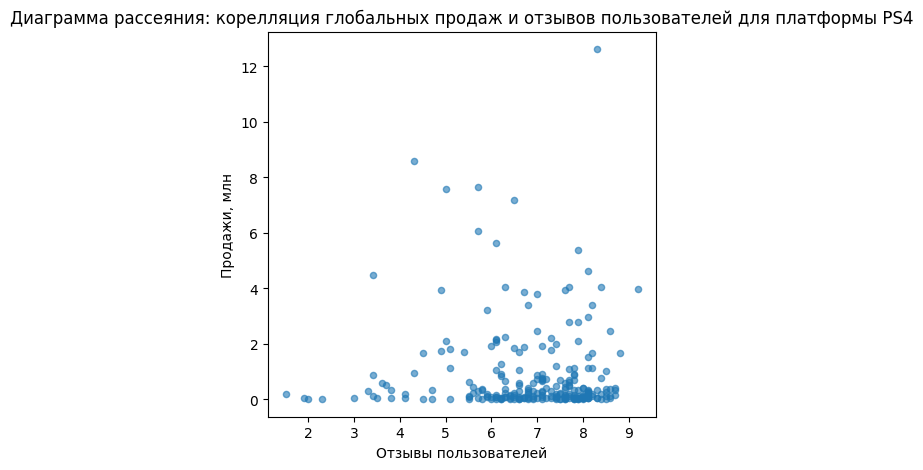

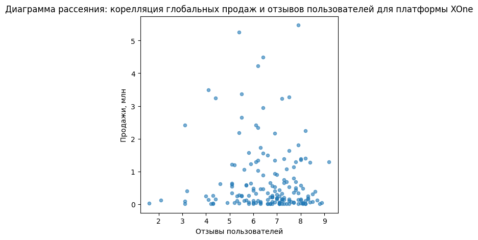

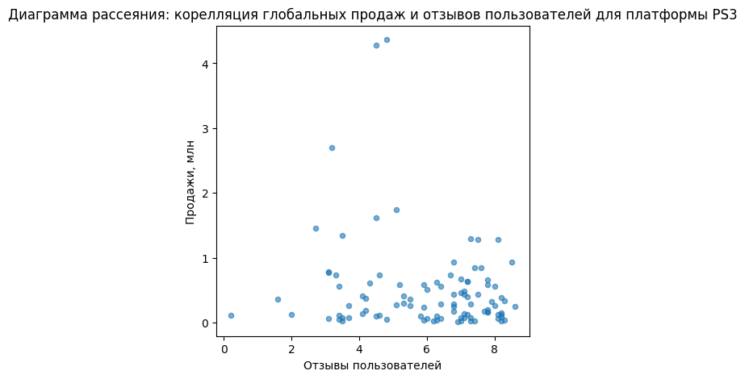

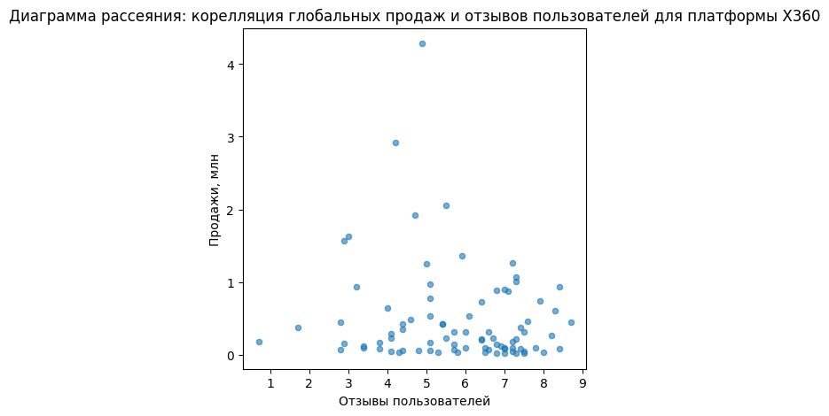

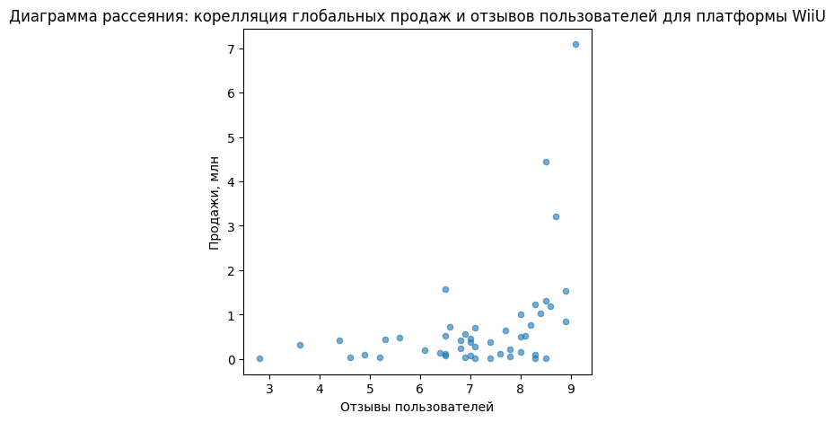

```python
for plat in (data_user
             .groupby('platform')['total_sales']
             .agg('sum')
             .sort_values(ascending=False)
             .head()
             .index
            ):
    #коэффициент корелляции
    print(f'Коэффициент корелляции между продажами и отзывами пользователей для платформы {plat}:',
      (data_user
       .query('platform == @plat')['total_sales']
       .corr(data_critic.query('platform == @plat')['user_score'])
      ),  '\n', '\n'
     )

    #диаграмма рассеяния
    (data_user
     .query('platform == @plat')
     .plot(kind='scatter', x='user_score', y='total_sales', alpha=0.6, figsize=(5, 5))
    )
    plt.title(f'Диаграмма рассеяния: корелляция глобальных продаж и отзывов пользователей для платформы {plat}')
    plt.xlabel('Отзывы пользователей')
    plt.ylabel('Продажи, млн');
```

Корелляция для самой популярной платформы **"PS4"** практически нулевая. Объёмы продажи игр, выпущенных на платформе **"PS4"**, не зависят от отзывов пользователей.

Для остальных платформ корелляция также от нулевой до слабой. Высокие отзывы пользователей как правило не означают хорошие продажи, и наоборот.

### Распределение игр по жанрам

```python
#сводная таблица
pivot_genres = data_act.pivot_table(
                index='genre',
                values='total_sales',
                aggfunc=['sum', 'median'],
                )
pivot_genres.columns = ['sum', 'median']
pivot_genres
```

| genre | sum | median |
| --- | --- | --- |
| Action | 199.36 | 0.090 |
| Adventure | 17.55 | 0.030 |
| Fighting | 28.22 | 0.125 |
| Misc | 37.55 | 0.090 |
| Platform | 18.09 | 0.140 |
| Puzzle | 2.21 | 0.045 |
| Racing | 27.52 | 0.090 |
| Role-Playing | 101.44 | 0.110 |
| Shooter | 170.94 | 0.515 |
| Simulation | 13.13 | 0.100 |
| Sports | 109.48 | 0.180 |
| Strategy | 3.96 | 0.060 |

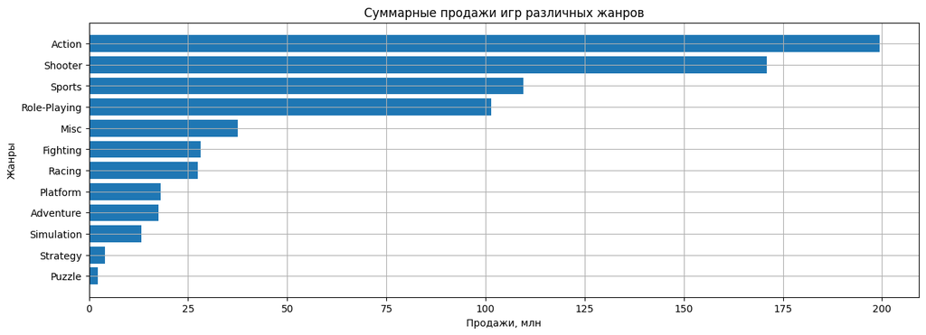

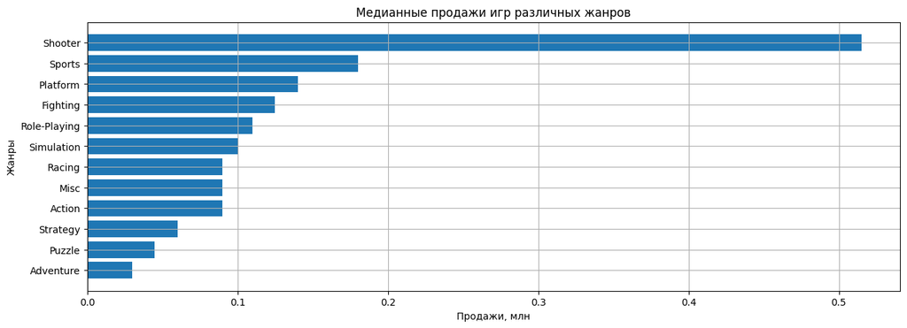

```python
#построение графика суммарных продаж
plt.figure(figsize=(15,5))
plt.barh(
    pivot_genres.sort_values(by='sum').index,
    pivot_genres.sort_values(by='sum')['sum']
);
plt.grid(True)
plt.ylabel('Жанры')
plt.xlabel('Продажи, млн')
plt.title('Суммарные продажи игр различных жанров')
plt.show()

#построение графика медианных продаж
plt.figure(figsize=(15,5))
plt.barh(
    pivot_genres.sort_values(by='median').index,
    pivot_genres.sort_values(by='median')['median']
);
plt.grid(True)
plt.ylabel('Жанры')
plt.xlabel('Продажи, млн')
plt.title('Медианные продажи игр различных жанров')
plt.show()
```

Однако если сравнить медианные значения продаж игр различных жанров, картина выглядит иначе:

- **Shooter** - лидирует с большим отрывом
- **Sports**
- **Platform**
- **Fighting**
- **Role-Playing**

Для прояснения этого вопроса можно построить диаграммы размаха для всех этих жанров.

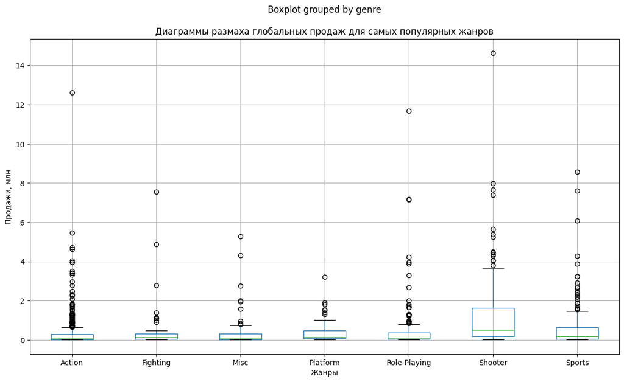

```python
(data_act
 .query('genre == ["Action", "Shooter", "Role-Playing", "Sports", "Misc", "Platform", "Fighting"]')
 .boxplot('total_sales', 'genre', figsize=(14,8))
);
plt.title('Диаграммы размаха глобальных продаж для самых популярных жанров')
plt.xlabel('Жанры')
plt.ylabel('Продажи, млн');
#plt.ylim(0, 1.6)
```

### Общий вывод по разделу

С 1980 по 1992 годы выпускали скромное по современным меркам количество игр. В начале 1980-х был небольшой бум выпуска игр, который сошёл на нет к 1990 году. Начиная с 1991 года наблюдается рост количествоа выпущенных игр, который с небольшими перерывами в 1999-2000 и 2002-2003 годах продолжался до максимума в 2008-2009 годах, а затем пошёл на спад, вероятно, сказался мировой экономический кризис 2008 года. Начиная с 2012 года количество выпущенных игр распределено сравнительно равномерно.

За весь наблюдаемый период 1980-2016 гг. можно выделить шесть наиболее популярных платформ:

- **PS2**
- **X360**
- **PS3**
- **Wii**
- **DS**
- **PS**

Наиболее актуальным и подходящим для анализа выглядит период 2014-2016 годов, поскольку это наиболее близкий к 2017 году период с относительно стабильной тенденцией количества выпущенных игр.

За выбранный период (2014-2016 годы) есть данные о 10 платформах. Наибольшие продажи демонстрируют 5 из них:

- **PS4**
- **XOne**
- **3DS**
- **PS3**
- **X360**

Платформа **PS4** лидирует с большим отрывом.

По объёмам продаж лидируют следующие платформы:

- **PS4**
- **XOne**
- **3DS**

Для каждой из рассматриваемых платформ есть относительно небольшое количество популярных игр и гораздо большая основная масса игр, притом суммарные продажи немногочисленных игр-лидеров сравнимы и могут даже превышать суммарные продажи большинства менее популярных игр.